# Análisis Exploratorio de Datos: Felicidad Global 2011–2024

Este notebook realiza un análisis exploratorio sobre los factores que influyen en el nivel de felicidad de los países a lo largo del tiempo, utilizando datos del World Happiness Report.

```
   Year  Rank Country name  Ladder score  upperwhisker  lowerwhisker  \
0  2024     1      Finland         7.736         7.810         7.662
1  2023   143  Afghanistan         1.721         1.775         1.667
2  2022   137  Afghanistan         1.859         1.923         1.795
3  2021   146  Afghanistan         2.404         2.469         2.339
4  2020   150  Afghanistan         2.523         2.596         2.449

   Explained by: Log GDP per capita  Explained by: Social support  \
0                             1.749                         1.783
1                             0.628                         0.000
2                             0.645                         0.000
3                             0.758                         0.000
4                             0.370                         0.000

   Explained by: Healthy life expectancy  \
```

[output cut: 19 more lines]

```
(1969, 13)
```

### Ver las columnas con sus nombres y tipos de datos

```
<class 'pandas.core.frame.DataFrame'>
RangeIndex: 1969 entries, 0 to 1968
Data columns (total 13 columns):
 #   Column                                      Non-Null Count  Dtype
---  ------                                      --------------  -----
 0   Year                                        1969 non-null   int64
 1   Rank                                        1969 non-null   int64
 2   Country name                                1969 non-null   object
 3   Ladder score                                1969 non-null   float64
 4   upperwhisker                                875 non-null    float64
 5   lowerwhisker                                875 non-null    float64
 6   Explained by: Log GDP per capita            872 non-null    float64
 7   Explained by: Social support                872 non-null    float64
 8   Explained by: Healthy life expectancy       870 non-null    float64
 9   Explained by: Freedom to make life choices  871 non-null    float64
 10  Explained by: Generosity                    872 non-null    float64
 11  Explained by: Perceptions of corruption     871 non-null    float64
 12  Dystopia + residual                         868 non-null    float64
dtypes: float64(10), int64(2), object(1)
memory usage: 200.1+ KB
None
```

```
Year                                            int64
Rank                                            int64
Country name                                   object
Ladder score                                  float64
upperwhisker                                  float64
lowerwhisker                                  float64
Explained by: Log GDP per capita              float64
Explained by: Social support                  float64
Explained by: Healthy life expectancy         float64
Explained by: Freedom to make life choices    float64
Explained by: Generosity                      float64
Explained by: Perceptions of corruption       float64
Dystopia + residual                           float64
dtype: object
```

### Ver los primeros registros con todas las columnas visibles

|  | Year | Rank | Country name | Ladder score | upperwhisker | lowerwhisker | Explained by: Log GDP per capita | Explained by: Social support | Explained by: Healthy life expectancy | Explained by: Freedom to make life choices | Explained by: Generosity | Explained by: Perceptions of corruption | Dystopia + residual |
| --- | --- | --- | --- | --- | --- | --- | --- | --- | --- | --- | --- | --- | --- |
| 0 | 2024 | 1 | Finland | 7.7360 | 7.81000 | 7.66200 | 1.749000 | 1.783000 | 0.824000 | 0.986 | 0.110000 | 0.502000 | 1.782000 |
| 1 | 2023 | 143 | Afghanistan | 1.7210 | 1.77500 | 1.66700 | 0.628000 | 0.000000 | 0.242000 | 0.000 | 0.091000 | 0.088000 | 0.672000 |
| 2 | 2022 | 137 | Afghanistan | 1.8590 | 1.92300 | 1.79500 | 0.645000 | 0.000000 | 0.087000 | 0.000 | 0.093000 | 0.059000 | 0.976000 |
| 3 | 2021 | 146 | Afghanistan | 2.4040 | 2.46900 | 2.33900 | 0.758000 | 0.000000 | 0.289000 | 0.000 | 0.089000 | 0.005000 | 1.263000 |
| 4 | 2020 | 150 | Afghanistan | 2.5230 | 2.59600 | 2.44900 | 0.370000 | 0.000000 | 0.126000 | 0.000 | 0.122000 | 0.010000 | 1.895000 |
| 5 | 2019 | 153 | Afghanistan | 2.5669 | 2.62827 | 2.50553 | 0.300706 | 0.356434 | 0.266052 | 0.000 | 0.135235 | 0.001226 | 1.507236 |
| 6 | 2018 | 154 | Afghanistan | 3.2030 | NaN | NaN | NaN | NaN | NaN | NaN | NaN | NaN | NaN |
| 7 | 2017 | 145 | Afghanistan | 3.6320 | NaN | NaN | NaN | NaN | NaN | NaN | NaN | NaN | NaN |
| 8 | 2016 | 141 | Afghanistan | 3.7940 | NaN | NaN | NaN | NaN | NaN | NaN | NaN | NaN | NaN |
| 9 | 2015 | 154 | Afghanistan | 3.3600 | NaN | NaN | NaN | NaN | NaN | NaN | NaN | NaN | NaN |

#### Vemos cuantos países y años hay en total en el dataframe

```
Total de países: 169
Total de años: 13
```

#### Vamos a documentar las columnas con el fin de poder explicar el significado de cada columna

#### 🧾 Descripción de las columnas del dataset - World Happiness Report

| Columna | Descripción |
| --- | --- |
| `Year` | Año en el que se midieron los datos. |
| `Country name` | Nombre del país. |
| `Ladder score` | Puntuación general de felicidad (escala 0 a 10). |
| `Rank` | Posición del país en el ranking global de felicidad. |
| `upperwhisker` / `lowerwhisker` | Límites superior e inferior del intervalo de confianza del `Ladder score`. |
| `Explained by: Log GDP per capita` | Parte del score explicada por el ingreso per cápita del país (logarítmico). |
| `Explained by: Social support` | Parte explicada por el apoyo social (familia, amigos, red de ayuda). |
| `Explained by: Healthy life expectancy` | Parte explicada por la expectativa de vida saludable. |
| `Explained by: Freedom to make life choices` | Parte explicada por la libertad percibida para tomar decisiones. |
| `Explained by: Generosity` | Parte explicada por la generosidad (donaciones, altruismo). |
| `Explained by: Perceptions of corruption` | Parte explicada por la corrupción percibida en gobierno/sociedad. |
| `Dystopia + residual` | Valor residual para completar el `Ladder score` (modelo interno). |

#### ¿Qué estamos analizando?

Cada fila representa un país en un año determinado.  
El objetivo es entender qué factores (PIB, salud, libertad, etc.) están más relacionados con la felicidad de los países según el World Happiness Report.

La columna `Ladder score` es la puntuación total de felicidad, y las columnas que empiezan por `Explained by:` explican cómo se construye ese score.

Antes de seguir con limpieza o visualización, es importante tener claro **qué mide cada variable** y **qué tipo de análisis nos interesa realizar** (por ejemplo: comparaciones por país, evolución temporal, correlaciones entre factores...).

#### Visualización general del dataset con los datos que tenemos completos (antes de la limpieza)

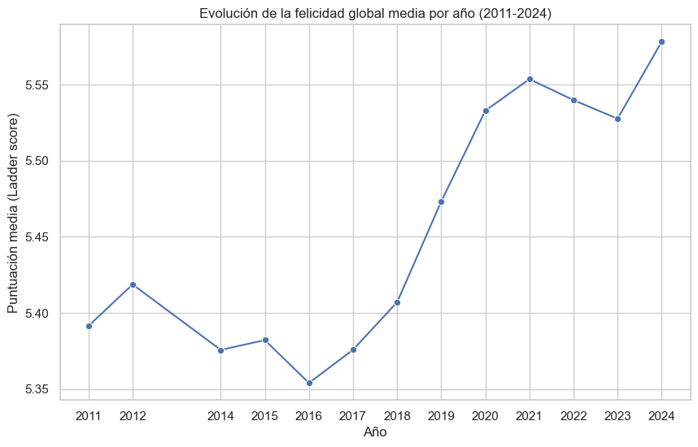

```
np.int64(2024)
```

### Ver los países más felices en el último año con datos completos

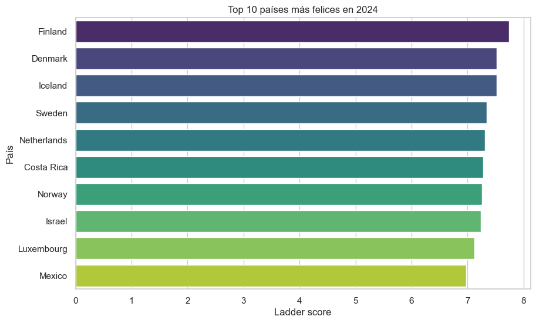

### Ver los países menos felices en el último año disponible

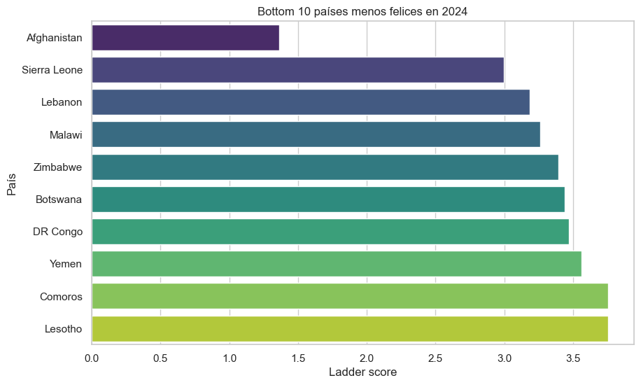

### Ver comparativa entre año más antiguo y más reciente

```
Primer año: 2011
Último año: 2024
```

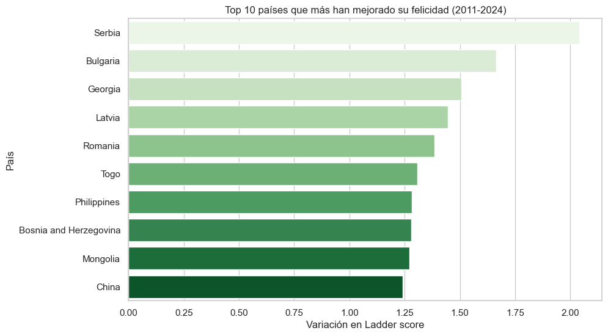

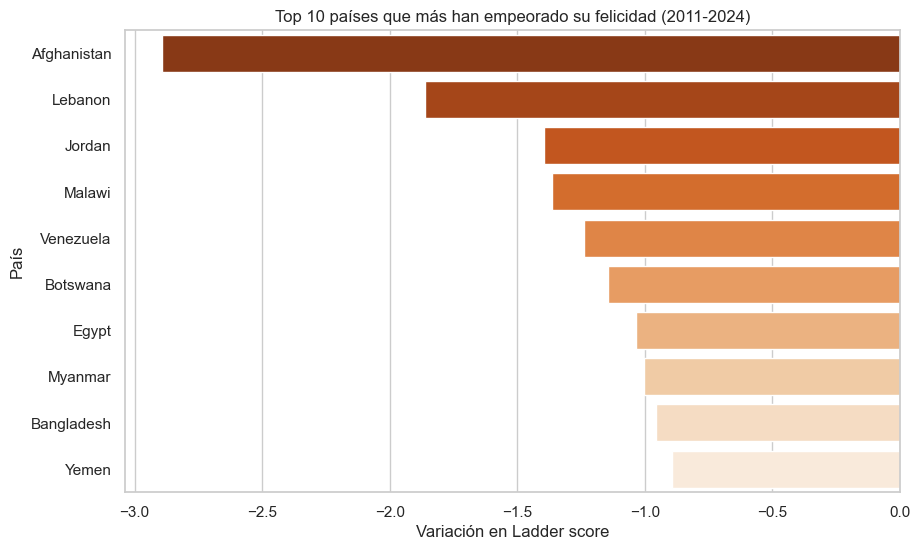

### 📊 Reflexión: Evolución de la felicidad global (2011–2024)

El análisis de la evolución de la felicidad entre 2011 y 2024 revela dos tendencias claras:

- 🟢 **Países que más han mejorado**: Serbia, Bulgaria, Georgia, Rumanía o Filipinas muestran un crecimiento significativo en su `Ladder score`. Muchos de estos países han atravesado procesos de estabilización política, integración europea o mejoras socioeconómicas en la última década.
- 🔴 **Países que más han empeorado**: Afganistán, Líbano, Jordania, Venezuela o Yemen han sufrido importantes retrocesos. Estos descensos reflejan contextos de **conflictos, crisis humanitarias o inestabilidad política y económica** que afectan directamente al bienestar de sus ciudadanos.

Estos resultados nos ayudan a entender que la felicidad no depende solo del desarrollo económico, sino también de **la estabilidad, la seguridad, la salud, y la gobernabilidad**. Este análisis aporta una visión valiosa antes de centrarnos en los factores que explican estos resultados.

### Lo que refleja este análisis:

- Correlación entre contextos geopolíticos y bienestar subjetivo.
- La herramienta Ladder score sí capta las grandes dinámicas sociales.
- La visualización sirve como base para formular hipótesis que luego contrastaremos con los factores (GDP, freedom, corruption, etc.).

### ✳️ Resumen del análisis exploratorio - Parte 1: Visualización general

Durante esta primera fase del análisis exploratorio del *World Happiness Report (2011–2024)*, se han llevado a cabo los siguientes pasos:

#### ⚙️ 1. Preparación del entorno

- Importación de librerías clave: `pandas`, `numpy`, `matplotlib`, `seaborn`.
- Carga y exploración inicial del dataset `.xlsx`.
- Revisión de estructura general, tipos de datos y valores nulos por columna.
- Documentación completa del significado de cada columna.

#### 👁️ 2. Visualización general y exploración de tendencias

- Evolución de la felicidad media global por año (`Ladder score`).
- Ranking de los países más felices y menos felices en el año más reciente disponible.
- Análisis comparativo de evolución entre 2011 y 2024:
  - 🔼 Países que más han **mejorado** su nivel de felicidad (ej. Serbia, Bulgaria, Georgia).
  - 🔽 Países que más han **empeorado** (ej. Afganistán, Líbano, Venezuela).

#### 📑 Conclusión de esta fase

Este análisis preliminar permite visualizar tendencias claras y contextualizar los datos antes de proceder a la limpieza y estudio de los factores que explican el `Ladder score`.

## Limpieza de datos.

1. 🔹Creamos un `df_limpio` con solo las filas completas en los factores explicativos
   - Esto nos dará un subconjunto sólido sobre el que hacer análisis de correlación y visualizaciones claras.
2. 🔹Ver cuántos datos nos quedamos y si hay suficiente variedad de países y años
   - Así evaluamos si podemos sacar conclusiones significativas.

```
Filas originales: 1969
Filas después de limpieza: 868
```

```
Años únicos: [2024 2023 2022 2021 2020 2019]
Número de países únicos: 157
```

```
Year
2019    153
2020    149
2021    146
2022    136
2023    140
2024    144
Name: count, dtype: int64
```

#### Comprobamos y eliminamos duplicados

```
Duplicados encontrados: 0
No se encontraron duplicados.
```

#### Verificar tipos de datos

```
Year                                            int64
Rank                                            int64
Country name                                   object
Ladder score                                  float64
upperwhisker                                  float64
lowerwhisker                                  float64
Explained by: Log GDP per capita              float64
Explained by: Social support                  float64
Explained by: Healthy life expectancy         float64
Explained by: Freedom to make life choices    float64
Explained by: Generosity                      float64
Explained by: Perceptions of corruption       float64
Dystopia + residual                           float64
dtype: object
```

### ✅ Se ha realizado una limpieza final del dataset

- Se ha verificado la presencia de duplicados: eliminados si existían.
- Se han revisado los tipos de datos de todas las columnas.
- El dataframe `df_limpio` está preparado para el análisis por factores, conteniendo solo filas con información completa y fiable.

## Análisis univariado de factores.

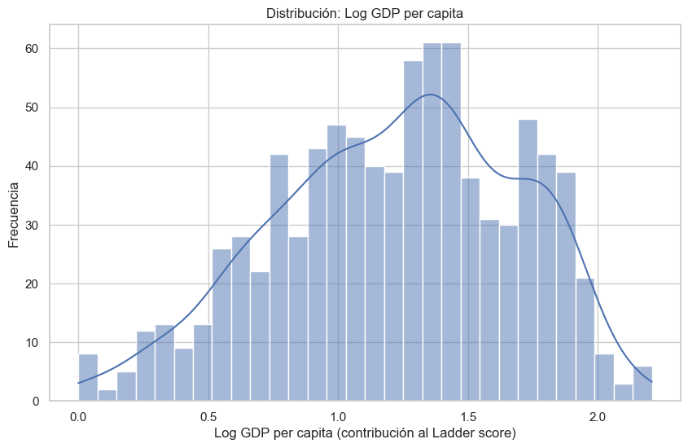

### 📊 Análisis univariado: Log GDP per capita

Este gráfico muestra la distribución de la contribución del PIB per cápita (en escala logarítmica) al índice de felicidad (`Ladder score`) entre países.

- La mayoría de países tienen una contribución entre **1.0 y 1.5 puntos**.
- Hay una pequeña cantidad de países muy pobres (valores cercanos a 0).
- También existen países con valores muy altos, próximos a 2.0 (muy desarrollados económicamente).
- La distribución muestra una leve inclinación hacia la izquierda, lo que indica que **el PIB suele tener un impacto medio-alto en la mayoría de países**, con pocos extremos.

Esto nos sugiere que el nivel económico del país tiene un peso importante en el bienestar percibido, pero no es homogéneo en todos los casos.

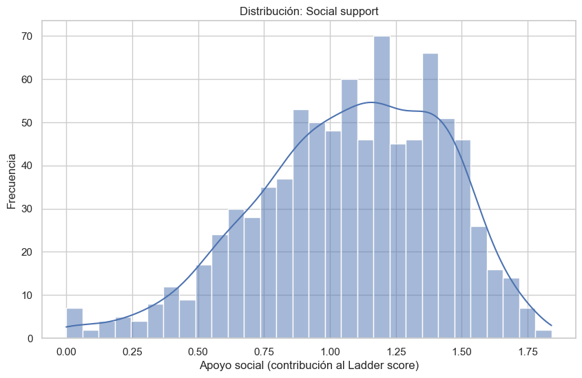

### 📊 Análisis univariado: Social support

Este gráfico muestra la distribución de la contribución del apoyo social al `Ladder score`.

- La mayoría de los países tienen valores entre **1.0 y 1.5**, lo que indica una alta influencia del apoyo social en el bienestar subjetivo.
- Muy pocos países se sitúan por debajo de 0.5 o por encima de 1.75.
- La forma de la distribución es parecida a la del PIB per cápita, lo que sugiere que el apoyo social también es un factor ampliamente relevante y comúnmente alto entre países.

Aunque parece ser un factor fuerte, necesitaremos observar su correlación con el `Ladder score` para confirmar su peso real en la felicidad global.

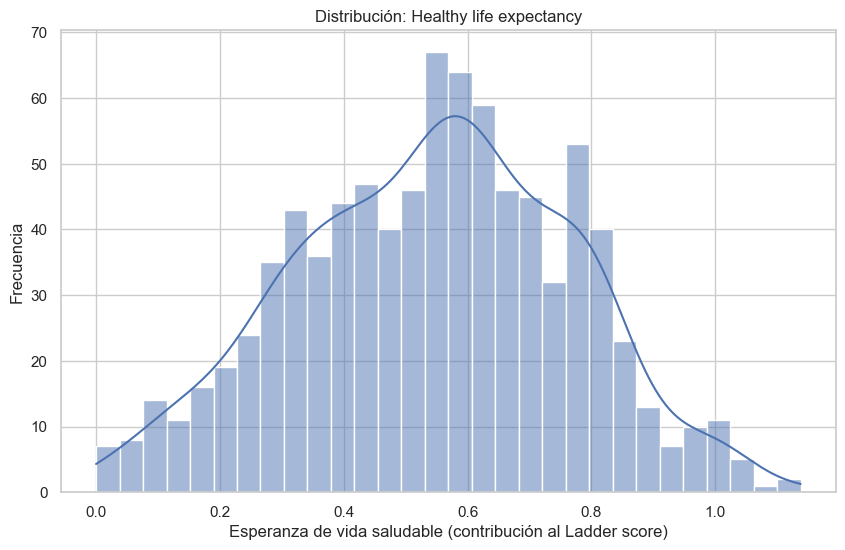

### 📊 Análisis univariado: Healthy life expectancy

Este gráfico muestra la distribución de la contribución de la esperanza de vida saludable al índice de felicidad (`Ladder score`).

- La mayoría de los países presentan valores entre **0.4 y 0.7**, lo que indica una aportación media al bienestar.
- La distribución es bastante simétrica, con pocos países por debajo de 0.2 o por encima de 0.9.
- A diferencia de factores como el PIB o el apoyo social, **las diferencias entre países son menos extremas**, lo que sugiere una cierta homogeneidad en este indicador a nivel global.

Aunque su variabilidad es menor, sigue siendo un factor importante que influye de forma estable en la felicidad de los países.

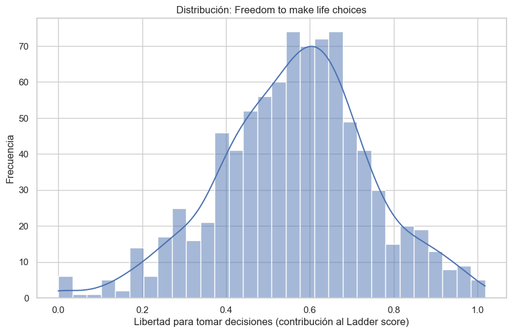

### 📊 Análisis univariado: Freedom to make life choices

Esta variable mide la percepción que tienen los ciudadanos sobre su libertad para tomar decisiones importantes en su vida.

- La mayoría de países tienen valores entre **0.4 y 0.7**, con un pico cercano a **0.6**.
- Hay pocos países con valores extremadamente bajos (por debajo de 0.2) o extremadamente altos (cercanos a 1).
- La distribución tiene forma ligeramente asimétrica, pero está bien concentrada en la zona media.

Este patrón sugiere que la libertad para tomar decisiones tiene una **influencia estable y significativa en la felicidad**, aunque con menor variabilidad entre países que otros factores como el PIB.

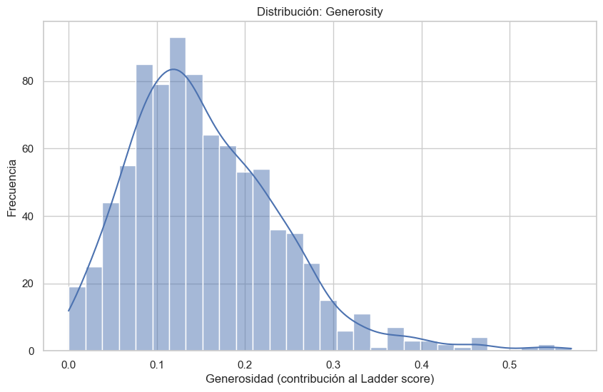

### 📊 Análisis univariado: Generosity

Este gráfico muestra la distribución de la contribución de la generosidad (medida como donaciones recientes) al índice de felicidad (`Ladder score`).

- La gran mayoría de países se sitúa por debajo de **0.2**, con un pico claro entre **0.1 y 0.15**.
- La distribución está claramente sesgada hacia la derecha, con pocos países que superan el 0.3.
- Esto sugiere que, aunque la generosidad pueda tener valor cultural o moral, **su impacto numérico en el índice de felicidad es bajo** en comparación con otros factores.

Podría ser relevante en casos concretos, pero **no parece ser un factor globalmente determinante**.

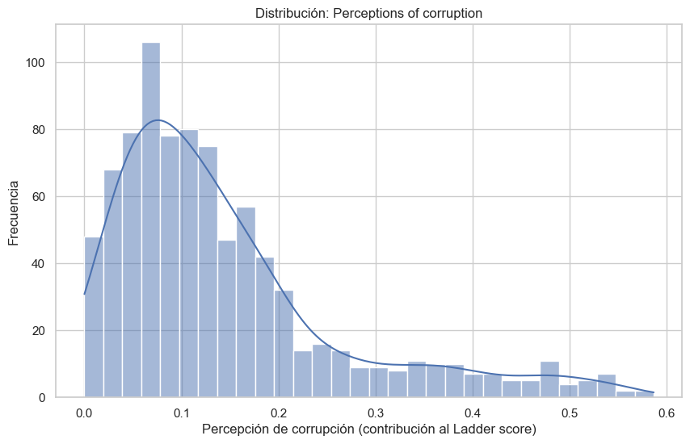

### 📊 Análisis univariado: Perceptions of corruption

Este gráfico muestra la distribución de la contribución de la percepción de corrupción al índice de felicidad (`Ladder score`).

- La mayoría de países se sitúan entre **0.05 y 0.2**, lo que refleja una percepción generalizada de corrupción en el mundo.
- Hay muy pocos países que superen 0.3, y casi ninguno llega al 0.6.
- La distribución es **claramente asimétrica hacia la derecha**, con un pico pronunciado cerca de 0.1.

## ✅ Resumen final – Análisis univariado de los factores explicativos

Durante esta fase hemos analizado uno por uno los factores que contribuyen al índice de felicidad (`Ladder score`), observando su distribución y comportamiento individual:

- **Log GDP per capita**: Factor económico con una amplia variabilidad entre países. Tiene un impacto claro y estable en la felicidad.
- **Social support**: Factor social ampliamente distribuido en niveles altos. Uno de los más homogéneos y relevantes.
- **Healthy life expectancy**: Factor sanitario con rango estrecho, lo que sugiere homogeneidad global en salud.
- **Freedom to make life choices**: Valor percibido moderado-alto en la mayoría de países. Influyente, pero con menor variabilidad.
- **Generosity**: Contribución baja en casi todos los países. Poca variabilidad y escaso peso global.
- **Perceptions of corruption**: Valor bajo en la mayoría de países. Aunque su impacto directo es pequeño, afecta negativamente a muchas sociedades.

> Este análisis nos permite entender cómo se comporta cada variable individualmente antes de analizar cómo se relacionan entre ellas y con el `Ladder score`.

### Análisis y cálculo de **correlaciones** entre variables.

```
Ladder score                                  1.000000
lowerwhisker                                  0.999501
upperwhisker                                  0.999468
Explained by: Log GDP per capita              0.688630
Explained by: Social support                  0.688275
Explained by: Healthy life expectancy         0.657776
Explained by: Freedom to make life choices    0.541575
Explained by: Perceptions of corruption       0.432127
Dystopia + residual                           0.414134
Explained by: Generosity                      0.042716
Year                                          0.023183
Rank                                         -0.976363
Name: Ladder score, dtype: float64
```

### 📊 Análisis de correlación – Factores explicativos vs. Felicidad

La correlación mide la **relación entre dos variables numéricas**. En este caso, nos interesa ver qué factores explicativos están **más relacionados con la felicidad**, medida por el `Ladder score`.

- La correlación toma valores entre **-1 y 1**:
  - **1.0** → relación perfecta positiva (sube uno, sube el otro)
  - **0.0** → sin relación
  - **-1.0** → relación perfecta inversa (sube uno, baja el otro)

### 📊 Resultados de la correlación con `Ladder score`

| Factor | Correlación | Interpretación |
| --- | --- | --- |
| `Log GDP per capita` | **0.6886** | Alta correlación: países más ricos, más felices |
| `Social support` | **0.6883** | Alta correlación: apoyo social = más felicidad |
| `Healthy life expectancy` | **0.6578** | Alta correlación: salud = bienestar |
| `Freedom to make life choices` | 0.5416 | Relación moderada-alta |
| `Perceptions of corruption` | 0.4321 | Relación moderada: menos corrupción, más felicidad |
| `Dystopia + residual` | 0.4141 | Parte no explicada del modelo, aún relevante |
| `Generosity` | 0.0427 | Correlación débil: no tiene efecto claro |
| `Year` | 0.0231 | Irrelevante en este contexto |

[output not shown]

### ✅ Conclusiones clave

- Los factores **económicos (PIB)**, **sociales (apoyo)** y de **salud (esperanza de vida)** son los **más influyentes** en la felicidad global.
- La **libertad y la corrupción** también tienen peso, aunque algo menor.
- Factores como la **generosidad** o el **año** apenas muestran relación directa con la felicidad.
- El análisis refuerza la idea de que el bienestar global depende de una **combinación equilibrada de desarrollo, salud, apoyo social y estabilidad institucional**.

#### Creamos un heatmap de correlaciones.

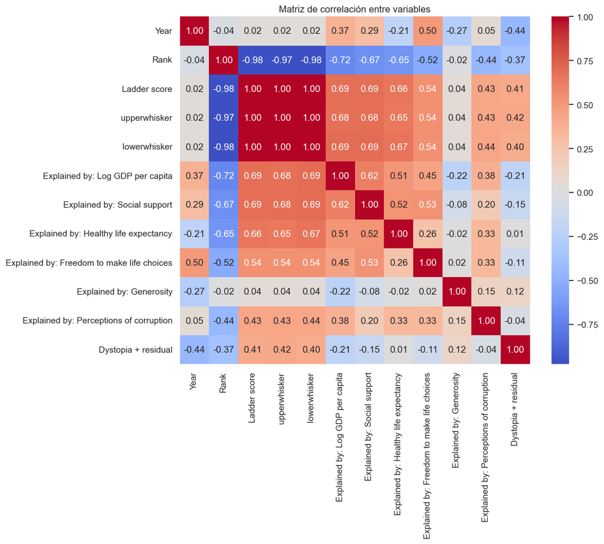

### 📊 Heatmap de correlaciones entre variables

El anterior gráfico nos muestra una matriz de correlación en forma de mapa de calor, donde se representan visualmente las relaciones entre todas las variables numéricas del dataset.

- Los valores cercanos a **1 (rojo oscuro)** indican una correlación positiva fuerte.
- Los valores cercanos a **-1 (azul oscuro)** indican una correlación negativa fuerte.
- Los valores próximos a **0** indican **poca o ninguna relación** entre las variables.

Este heatmap nos permite ver de forma rápida qué variables están más relacionadas entre sí y con el índice de felicidad (`Ladder score`). Reforzamos así los hallazgos del análisis numérico, confirmando que los factores con más influencia positiva son el **PIB per cápita**, el **apoyo social** y la **esperanza de vida saludable**.

#### Creamos scatterplots con línea de regresión (aunque no es necesario, si es potente visualmente).

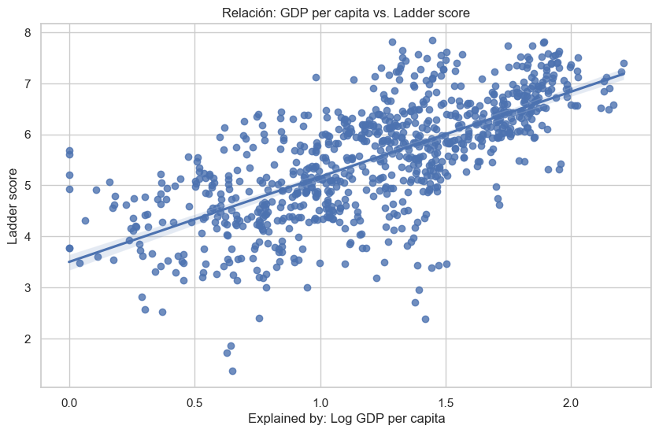

### 📈 Relación entre PIB per cápita y felicidad

Este gráfico de dispersión muestra la relación entre el PIB per cápita (en escala logarítmica) y el índice de felicidad (`Ladder score`) para todos los países del dataset.

- Cada punto representa un país en un año determinado.
- La línea azul muestra una **tendencia lineal ajustada por regresión**, que permite ver claramente que a **mayor PIB**, generalmente **mayor nivel de felicidad**.

Este tipo de gráfico nos ayuda a **visualizar la fuerza y la forma de la relación** entre variables. En este caso, confirma lo observado en la matriz de correlación: el PIB es uno de los factores más determinantes en la felicidad media de los países.

Este patrón sugiere que el PIB per cápita no solo está correlacionado con la felicidad, sino que **su efecto es bastante lineal y predecible**, lo que lo convierte en uno de los factores más estables y determinantes del conjunto.

## ✅ Conclusiones del análisis multivariable

Tras explorar la relación entre los distintos factores explicativos y el índice de felicidad (`Ladder score`), podemos extraer las siguientes conclusiones clave:

### 🔹 1. Factores más influyentes

El análisis de correlación revela que los factores más relacionados con la felicidad son:

- **PIB per cápita (`Log GDP`)** → correlación de 0.69
- **Apoyo social (`Social support`)** → 0.69
- **Esperanza de vida saludable (`Healthy life expectancy`)** → 0.66

Estos factores presentan tanto **alta correlación numérica** como **una relación visual clara** en los gráficos de dispersión, con una tendencia positiva bien definida.

### 🔹 2. Factores moderadamente influyentes

- **Libertad para tomar decisiones** (correlación ~0.54)
- **Percepción de corrupción** (correlación ~0.43)

Ambos tienen una relación real con la felicidad, aunque más débil que los anteriores. Aportan contexto social y político importante.

### 🔹 3. Factores menos determinantes

- **Generosidad** y **año** presentan una correlación muy baja con la felicidad.
- Aunque puedan tener valor cultural o ético, no parecen ser factores predictivos significativos en este análisis global.

### 🔹 4. Visualizaciones clave

- El **heatmap de correlaciones** refuerza visualmente todas estas conclusiones, mostrando claramente los vínculos fuertes y débiles.
- El **scatterplot entre PIB y felicidad** evidencia una relación sólida, lineal y creciente, lo que consolida su papel como uno de los factores más estables del conjunto.

📌 Estas conclusiones nos van a permitir identificar con claridad **qué variables explican mejor las diferencias de felicidad entre países** y nos van a servir de base para el informe final.

### 🌍 Mapa de la Evolución de la Felicidad en el Mundo (2011-2024)

```
Index(['Year', 'Rank', 'Country name', 'Ladder score', 'upperwhisker',
       'lowerwhisker', 'Explained by: Log GDP per capita',
       'Explained by: Social support', 'Explained by: Healthy life expectancy',
       'Explained by: Freedom to make life choices',
       'Explained by: Generosity', 'Explained by: Perceptions of corruption',
       'Dystopia + residual'],
      dtype='object')
```

[interactive chart not shown]

El deslizador temporal permite analizar cómo ha cambiado la percepción de la felicidad en el mundo entre 2011 y 2024, proporcionando una visión clara de las tendencias globales

### Mapa mundial interactivo del índice de felicidad (2019–2024)

[interactive chart not shown]

Visualización coroplética que muestra la evolución del Ladder score por país. El deslizador temporal permite analizar cómo ha cambiado la percepción de felicidad en el mundo entre 2019 y 2024.

🎯 Objetivo: Ver la distribución global del Ladder score en un mapa interactivo.

### Evolución del índice de felicidad en países con mayor cambio (2011–2024)

[figure not shown]

Gráfico comparativo de los países que más han incrementado o disminuido su felicidad entre 2011 y 2024. Se observa cómo han evolucionado sus puntuaciones en el Ladder score a lo largo del tiempo, revelando patrones de mejora o deterioro sostenido.

# Expectativa de vida saludable VS Apoyo social VS Felicidad

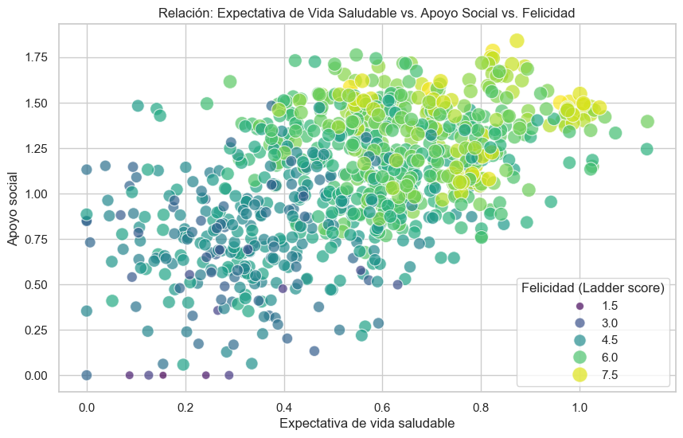

## ¿Influye la esperanza de vida y el apoyo social en la felicidad?

### Interpretación de la gráfica:

- **Relación entre expectativa de vida y apoyo social:** Existe una correlación directa entre la expectativa de vida saludable y el apoyo social. A medida que el apoyo social aumenta, también lo hace la esperanza de vida saludable, lo que indica que una mayor interacción social y redes de apoyo pueden estar contribuyendo a la longevidad saludable.
- **Impacto de la felicidad:** Los países con mayor expectativa de vida saludable y apoyo social también presentan puntuaciones más altas en el Ladder score. Esto sugiere que el bienestar emocional y social (es decir, sentirse apoyado y tener una vida saludable) está relacionado con una mayor satisfacción con la vida y un mayor sentido de felicidad.
- **Efecto positivo del apoyo social:** El apoyo social no solo parece influir en la longevidad, sino que también podría estar mejorando la salud mental de las personas. Esto es consistente con estudios previos que muestran que las redes sociales fuertes y el soporte emocional tienen un impacto significativo en la salud general y la felicidad.

## Conclusión 💡

La combinación de una **longevidad saludable** y un fuerte **apoyo social** parece tener un efecto positivo en la **felicidad**, lo que refuerza la importancia de cultivar tanto la salud física como las relaciones sociales para mejorar la calidad de vida. La evidencia sugiere que no solo la salud física, sino también el bienestar emocional y las redes de apoyo juegan un papel crucial en el nivel de satisfacción y felicidad de las personas.

```
c:\Users\USUARIO\desktop\factoria-f5\biap4\WorldHappinessEDA_extend\notebooks
statsmodels version: 0.14.4
c:\Users\USUARIO\Desktop\factoria-f5\biap4\WorldHappinessEDA_extend\venv\Scripts\python.exe
   Year  Rank Country name  Ladder score  upperwhisker  lowerwhisker  \
1  2023   143  Afghanistan        1.7210       1.77500       1.66700
2  2022   137  Afghanistan        1.8590       1.92300       1.79500
3  2021   146  Afghanistan        2.4040       2.46900       2.33900
4  2020   150  Afghanistan        2.5230       2.59600       2.44900
5  2019   153  Afghanistan        2.5669       2.62827       2.50553

   Explained by: Log GDP per capita  Explained by: Social support  \
1                          0.628000                      0.000000
2                          0.645000                      0.000000
3                          0.758000                      0.000000
4                          0.370000                      0.000000
5                          0.300706                      0.356434

   Explained by: Healthy life expectancy  \
1                               0.242000
2                               0.087000
3                               0.289000
4                               0.126000
5                               0.266052

   Explained by: Freedom to make life choices  Explained by: Generosity  \
1                                         0.0                  0.091000
2                                         0.0                  0.093000
3                                         0.0                  0.089000
4                                         0.0                  0.122000
5                                         0.0                  0.135235

   Explained by: Perceptions of corruption  Dystopia + residual  \
1                                 0.088000             0.672000
2                                 0.059000             0.976000
3                                 0.005000             1.263000
4                                 0.010000             1.895000
5                                 0.001226             1.507236

  School enrollment, tertiary (% gross) School enrollment, secondary (% gross)
1                                    ..                                     ..
2                                    ..                                     ..
3                                    ..                                     ..
4                      10.8584403991699                                     ..
5                                    ..                                     ..
```

## Análisis de la relación entre felicidad y nivel de estudios

Este notebook realiza un análisis para explorar la relación entre la felicidad de un país y el nivel de estudios de su población, siguiendo las indicaciones proporcionadas.

### 1. Pruebas de Normalidad

Primero, evaluaremos si las variables de felicidad y nivel de estudios siguen una distribución normal utilizando la prueba de Shapiro-Wilk.

```
Prueba de Shapiro-Wilk para la felicidad: ShapiroResult(statistic=np.float64(0.985072735139167), pvalue=np.float64(3.6909755450683183e-06))
Prueba de Shapiro-Wilk para el nivel de estudios terciario: ShapiroResult(statistic=np.float64(0.9631573325118252), pvalue=np.float64(4.268978491690233e-09))
```

### 2. Pruebas de Correlación

Dado que las variables no siguen una distribución normal (según la prueba de Shapiro-Wilk), utilizaremos la prueba de correlación de Spearman para evaluar la relación entre la felicidad y el nivel de estudios.

```
Correlación de Spearman (felicidad vs. estudios terciarios): 0.4711187141031493 Valor p: 6.034058877091798e-37
Correlación de Spearman (felicidad vs. estudios secundarios): 0.07456949643516778 Valor p: 0.058385438514511015
```

### 3. Visualizaciones

A continuación, generaremos algunas visualizaciones para explorar la relación entre las variables.

#### Diagramas de dispersión

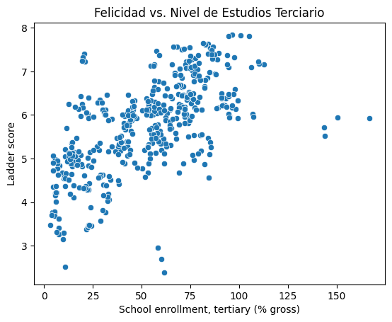

[figure not shown]

#### Histogramas

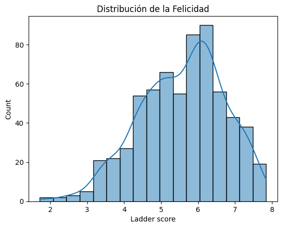

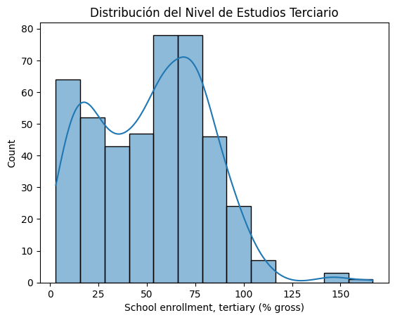

[figure not shown]

#### Gráficos de series de tiempo

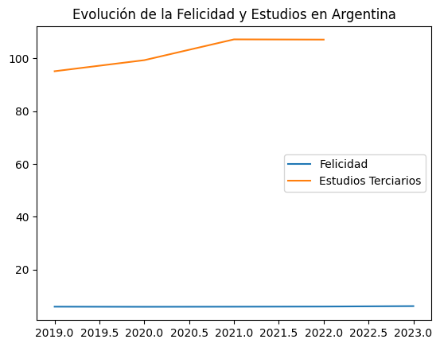

#### Matrices de correlación

[figure not shown]

### 4. Interpretación de resultados

La correlación no implica causalidad. Aunque encontramos una correlación positiva entre la educación terciaria y la felicidad, no podemos concluir que una cause la otra. Podría haber otros factores subyacentes (como el desarrollo económico, la calidad de vida general, las políticas sociales, etc.) que influyen en ambos.

Es importante considerar otros factores. La felicidad es un fenómeno complejo influenciado por múltiples variables. Este análisis se ha centrado en la educación, pero sería valioso explorar la relación con otras variables presentes en el conjunto de datos (como el PIB per cápita, el apoyo social, la esperanza de vida saludable, la libertad para tomar decisiones de vida, la generosidad,y la percepción de corrupción, etc.).

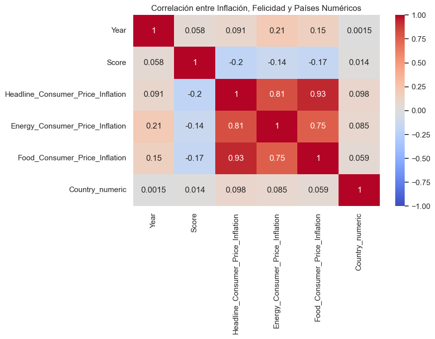

[figure not shown]